# Movies-EDA

[figure not shown]

##### Blog

```python
%matplotlib inline
```

```python
import math

import numpy as np
import pandas as pd

import matplotlib as mpl
import matplotlib.pyplot as plt
import matplotlib.ticker as mtick

import networkx as nx

import skimage.io

from matplotlib.patches import Polygon
from matplotlib.collections import PatchCollection

from scipy import stats

# Importing Basemap without these two lines doesn't work on my machine,
# UGH!!! .. the path is not username specific at least!
# If there are problems on your machine, remove them...
# I just couldn't be bothered with reinstalling stuff right now! Sorry!
import os
os.environ["PROJ_LIB"] = "C:/ProgramData/Anaconda3/Lib/site-packages/mpl_toolkits/basemap"
from mpl_toolkits.basemap import Basemap

import string

from sklearn.feature_extraction.text import TfidfVectorizer
from sklearn.model_selection import train_test_split

import nltk
from nltk.stem import WordNetLemmatizer
nltk.download('wordnet')

plt.style.use("ggplot")
```

# Movies EDA

### Introduction

We will explore a large data set movies and see if we can answer these questions:

- Are more movies being released in recent years?
- Are certain genres more popular throughout the years?
- Does runtime depend on the genre of the movie?
- Is there a link between runtime and quality of the movie?
- Is there a link between movie genres and poster color intensity?
- .. and at the end: an idea for trying to predict movie genre based on most common words in its overview/subtitles.

### The Data

The data we are going to use is the following set from kaggle.com:

- [350 000+ movies from themoviedb.org](https://www.kaggle.com/stephanerappeneau/350-000-movies-from-themoviedborg) provided by Stephanerappeneau (Last updated in 2017)

We are going to extract that archive in `data/350000_movies_dataset`.

```python
movie_details = pd.read_csv("data/350000_movies_dataset/AllMoviesDetailsCleaned.csv", sep = ";", thousands = ",",
                            encoding = "utf-8-sig", index_col = [0], parse_dates = ["release_date"], low_memory = False)
```

### The Cleaning

First of all, let's remove the columns which we won't need.

```python
movie_details_cleaned = movie_details.drop(["original_title", "original_language", "spoken_languages_number",
                                            "tagline", "production_companies", "production_companies_number",
                                            "budget", "revenue"], axis = 1)
```

Movies with no titles might be just missing data. We will discard those.

Let's also rename some columns and fix column types. Pandas supports a nullable int type so we will use that for the runtime.

```python
movie_details_cleaned = movie_details_cleaned[~movie_details_cleaned.title.isnull()]

# After looking through 'production_countries' it only ever contains only one country?
movie_details_cleaned = movie_details_cleaned.rename(columns = {"production_countries": "country"})
movie_details_cleaned = movie_details_cleaned.drop("production_countries_number", axis = 1, errors = "ignore")
# .. same with "spoken_languages"
movie_details_cleaned = movie_details_cleaned.rename(columns = {"spoken_languages": "language"})

movie_details_cleaned.runtime = movie_details_cleaned.runtime.astype(float).replace(0, float("NaN")).astype("Int64")
```

The `language` and `country` columns contain values that signify missing data. Let's convert all of them to `np.nan`:

```python
def clean_values_from_columns(data, cols, values, replace = np.nan):
    """
    `data` - the data set
    `cols` - a list of the the names of the columns as a string
    `values` - a list of values which should be cleaned
    `replace` - the value which replaces them (by default nan)
    """
    for value in values:
        for col in cols:
            data[col] = data[col].replace(value, replace)
```

```python
clean_values_from_columns(movie_details_cleaned, ["language"], ["?????", "??????", "No Language", "none"])
clean_values_from_columns(movie_details_cleaned, ["country"], ["none"])
```

All non-null values in `imdb_id` start with `tt` for some reason.

```python
imdb_id = movie_details.imdb_id.str.replace("tt", "")
imdb_id = pd.to_numeric(imdb_id, errors = "coerce").astype(str).str.slice(0, -2).replace("n", np.nan)
movie_details_cleaned.imdb_id = imdb_id
```

Finally, let's reorder the columns so it looks nicer:

```python
movie_details_cleaned = movie_details_cleaned[["release_date", "status", "title", "overview",
                                               "genres", "country", "language", "runtime", "popularity",
                                               "vote_average", "vote_count", "imdb_id"]]
```

```python
movie_details = movie_details_cleaned
del movie_details_cleaned
```

The final columns are the following:

- `release_date`
- `status` - Released, In Production, Post Production, Planned, Rumored, Canceled
- `title` - translated in English for foreign movies
- `overview` - a short text describing the movie
- `genres` - a list separated by "|"
- `country` - the country in which the movie was produced
- `language` - the language that is spoken in the movie
- `runtime` - in minutes
- `popularity` - relative popularity of the movie (at the time of gathering the information I guess). This number is from `themoviedb.org`
- `vote_average` - the average rating (0 - 10)
- `vote_count` - number of people who have given a rating
- `imdb_id` - the id of the movie in https://www.imdb.com/ (we will later join that with another data set)

This is how the data looks now:

```python
movie_details.info()
```

```
<class 'pandas.core.frame.DataFrame'>
Int64Index: 329043 entries, 2 to 469219
Data columns (total 12 columns):
 #   Column        Non-Null Count   Dtype
---  ------        --------------   -----
 0   release_date  304997 non-null  datetime64[ns]
 1   status        327055 non-null  object
 2   title         329043 non-null  object
 3   overview      278060 non-null  object
 4   genres        207515 non-null  object
 5   country       177084 non-null  object
 6   language      179170 non-null  object
 7   runtime       227462 non-null  Int64
 8   popularity    329043 non-null  float64
 9   vote_average  329043 non-null  float64
 10  vote_count    329043 non-null  int64
 11  imdb_id       250422 non-null  object
dtypes: Int64(1), datetime64[ns](1), float64(2), int64(1), object(7)
memory usage: 32.9+ MB
```

```python
movie_details.sample(n = 5, random_state = 12)
```

| id | release_date | status | title | overview | genres | country | language | runtime | popularity | vote_average | vote_count | imdb_id |
| --- | --- | --- | --- | --- | --- | --- | --- | --- | --- | --- | --- | --- |
| 200530 | 1980-12-02 | Released | Tortura Cruel | NaN | Crime\|Thriller | NaN | Português | <NA> | 0.014658 | 0.0 | 0 | 261360 |
| 167025 | 1997-10-21 | Released | Maniac Killer | NaN | Horror | Germany | Deutsch | <NA> | 0.028866 | 4.0 | 1 | 1420556 |
| 88758 | 1986-02-21 | Released | Getting Even | A soldier-of-fortune steals some Russian nerve... | NaN | NaN | NaN | 89 | 0.015000 | 2.0 | 2 | 91108 |
| 41564 | 2009-01-28 | Released | Blessed Is the Match: The Life and Death of Ha... | The story of Hannah Senesh, a Hungarian poet w... | Documentary | NaN | NaN | 86 | 0.000579 | 8.0 | 2 | 814031 |
| 694 | 1980-05-22 | Released | The Shining | Jack Torrance accepts a caretaker job at the O... | Horror\|Thriller | United Kingdom | English | 144 | 10.738001 | 8.0 | 3322 | 81505 |

The data set contains entries which have the genre "foreign" which I guess means produced outside the USA. Since "foreign" is a vague genre and really depends on what country you are in, let's remove it from the data all together.

```python
movie_details.genres = movie_details.genres.str.replace("(\|)?Foreign", "")
movie_details.genres = movie_details.genres.str.replace("^(\|)", "")
```

Our data contains a number of movies with a runtime over 300 minutes (5 hours). "Those films are experimental in nature or created for art gallery installations, having never been simultaneously released to multiple screens or intended for mainstream audiences. They may have been shown in venues where audiences were only expected to view a portion of the film during its screening."

There is a wikipedia article with a [list of long movies](https://en.wikipedia.org/wiki/List_of_longest_films).

We will treat them as outliers which we can safely discard from the data set since they make up such a little fraction of it.

```python
movies_with_runtime = movie_details[~movie_details.runtime.isnull()]
long_movies = movies_with_runtime.runtime[movies_with_runtime.runtime > 300]
long_movies.shape[0], movie_details.shape[0]
```

```
(881, 329043)
```

```python
d, dd = long_movies.shape[0], movie_details.shape[0]
print(f"Long movies were {d} / {dd} = {round(d / dd * 100, 2)}% of the data set.")
```

```
Long movies were 881 / 329043 = 0.27% of the data set.
```

```python
movie_details = movie_details.drop(long_movies.index)
```

### Different characteristics over the years

#### Number of movies per year

Let's take the movies which have been released and plot them by year.

```python
movies_released = movie_details[movie_details.status == "Released"]
movies_released = movies_released.drop("status", axis = 1)
movies_released = movies_released[~movies_released.release_date.isnull()]
```

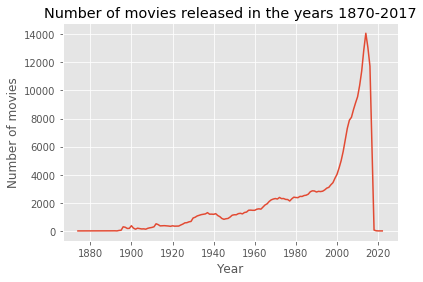

```python
number_of_movies_by_year = movies_released.groupby(movies_released.release_date.dt.year).count().release_date

plt.plot(number_of_movies_by_year.index, number_of_movies_by_year)
plt.title("Number of movies released in the years 1870-2017")
plt.xlabel("Year")
plt.ylabel("Number of movies")
plt.show()
```

Our data suggests that movies are getting more and more popular.

But we can also see that there is a big dip after around 2017. That's probably not because people suddenly stopped making movies.\ There are a few explanations:

1. Our dataset was actually taken in 2017. So that explains a big chunk of missing information for the recent years.
2. Not all movies have been released. Some are in production/post production or planned.

Let's see all records of movies before 1890:

```python
movies_released[movies_released.release_date.dt.year < 1890][["release_date", "title", "overview", "genres", "runtime"]]
```

| id | release_date | title | overview | genres | runtime |
| --- | --- | --- | --- | --- | --- |
| 16463 | 1888-10-14 | Roundhay Garden Scene | The earliest surviving celluloid film, and bel... | History\|Documentary | 1 |
| 16464 | 1888-10-15 | Traffic Crossing Leeds Bridge | A film by Louis Aimé Augustin Le Prince, shot ... | Documentary | 1 |
| 96882 | 1888-01-01 | Accordion Player | The last remaining film of Le Prince's LPCCP T... | Documentary | 1 |
| 159897 | 1887-08-18 | Man Walking Around a Corner | The last remaining production of Le Prince's L... | Documentary | 1 |
| 194079 | 1878-06-14 | Sallie Gardner at a Gallop | Sallie Gardner at a Gallop was one of the earl... | Documentary | 1 |
| 315946 | 1874-12-09 | Passage of Venus | Photo sequence of the rare transit of Venus ov... | Documentary | 1 |
| 335765 | 1888-05-31 | Pferd und Reiter Springen Über ein Hindernis | A horse with rider jumping over an obstacle. A... | Documentary | 1 |
| 355764 | 1889-01-01 | Hyde Park Corner | Lost film from 1889 | NaN | 1 |
| 355995 | 1888-01-01 | Brighton Street Scene | Lost film from 1888, directed by William Fries... | NaN | 1 |
| 421315 | 1884-01-01 | Human Figure in Motion | Muybridge first photographed the human figure ... | Documentary | 2 |
| 421316 | 1884-01-01 | Descending Stairs and Turning Around | Eadweard Muybridge, ‘Descending Stairs and Tur... | Documentary | 1 |
| 426903 | 1883-11-19 | Buffalo Running | Individual photographs of the running of a buf... | Documentary | 1 |

These are some of the first films ever. They were only 1-2 minutes long and had a very basic concept (e.g. "Human Figure in Motion").

Of course as technology advanced and more capabilities were available, the medium gained popularity, leading to the spike of movies being made after the 2000s.

If seems though as the curve grows too quickly. Maybe our dataset is biased towards recent movies?

[This article](https://stephenfollows.com/how-many-films-are-released-each-year/) reaches a conclusion that way more movies are being made in recent years. But not as much. **According to it the growth is around twice as much movies released in 2016 compared to 2000. That is significantly less than what our plot shows.**

Going forward we should keep in mind that release date is most likely biased towards recent years.

#### Genre popularity

Are certain genres more popular throughout the years?

First we must figure out the unique genres contained in the dataset. Which is way more complicated than `movies_released.genres.unique()`. The entries in the dataset contain multiple genres as a string separated by `|`.

```python
# Get the movies which don't have missing genres
movie_details_genres = movies_released[~movies_released.genres.isnull()]
```

```python
unique_genres = set()
for index, genres in movie_details_genres.genres.str.split("|").items():
    for genre in genres:
        if genre == "": continue
        unique_genres.add(genre)
print(unique_genres)
```

```
{'Mystery', 'Science Fiction', 'Family', 'History', 'Western', 'Fantasy', 'Music', 'Comedy', 'TV Movie', 'Documentary', 'Horror', 'Thriller', 'Adventure', 'Drama', 'Animation', 'Romance', 'Crime', 'Action', 'War'}
```

Now we split the dataset into multiple smaller ones based on genre and save them in a dict.\ We also take movies after the year 1900 since there too few movies per year before that.

```python
movie_details_grouped_by_genre = dict()
for genre in unique_genres:
    movie_details_grouped_by_genre[genre] = movie_details_genres[(movie_details_genres.genres.str.contains(genre))
                                                                  & (movie_details_genres.release_date.dt.year > 1900)]
```

We can now plot all genres in the same way we plotted the number of movies per year above:

```python
def plot_all_genres_naive():
    for genre in unique_genres:
        df = movie_details_grouped_by_genre[genre]
        number_of_movies_by_genre_by_year = df.groupby(df.release_date.dt.year).count().release_date

        plt.title(f"Number of movies (genre = {genre}) released in the years 1870-2017")
        plt.plot(number_of_movies_by_genre_by_year.index, number_of_movies_by_genre_by_year)

        plt.xlabel("Year")
        plt.ylabel("Number of movies")

        plt.ylim(0, 3500) # Make the scale between the plots the same
        plt.show()
# plot_all_genres_naive()
```

If you run it (I've commented it out on purpose to reduce clutter) you can see it's a very horrible. It's hard to see the differences between genres and doesn't really show the popularity (just the number of movies, and that follows the same curve we saw earlier - way more movies in each genre in the recent years because of way more movies in general and the bias in our data).

We can do better. Instead, for a given genre, we will calculate the percentage of all movies released that year which were in that genre. We also arrange the plots side by side for a more compact view.

```python
def plot_by_genre_side_by_side(title, plot_func):
    """
    `title` - the title of the entire figure
    `plot_func` - called for each funtion, must take parameters (genre, ax)
    """
    ncols = 4
    nrows = math.ceil(len(unique_genres) / 4)

    fig, axes = plt.subplots(nrows = nrows, ncols = ncols, figsize = (14, 9))
    fig.suptitle(title, fontsize = 18, y = 1.025)

    row, col = 0, 0
    for genre in unique_genres:
        ax = axes[row, col]
        ax.set_title(str(genre))

        plot_func(genre, ax)

        col += 1
        if col == ncols:
            row += 1
            col = 0
    plt.tight_layout()
    plt.show()
```

```python
percentages = dict()

for genre in unique_genres:
    genre_data = movie_details_grouped_by_genre[genre]
    percentage = genre_data.groupby(genre_data.release_date.dt.year).count().release_date
    percentages[genre] = percentage / number_of_movies_by_year
```

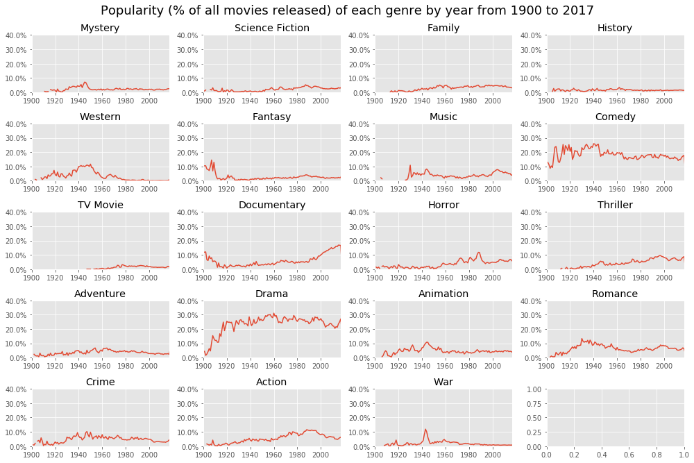

```python
def genre_popularity_plotter(genre, ax):
    p = percentages[genre]
    ax.plot(p.index, p)

    ax.set_ylim(0, 0.4) # Make the scale between 0 and 100 percent
    ax.yaxis.set_major_formatter(mtick.PercentFormatter(1.0))
    ax.set_xlim(1900, 2017)

plot_by_genre_side_by_side("Popularity (% of all movies released) of each genre by year from 1900 to 2017", genre_popularity_plotter)
```

```python
del percentages
```

### Differences in runtime by genre

Does runtime depend on the genre of the movie?

We made our `plot_by_genre_side_by_side` function general. So let's plot histograms of movie runtimes by genre.

Also, let's plot them with `density = True`. This "normalizes" the histograms so they don't depend on the number of inputs of a given genre - earlier we saw there are a lot more comedy/drama movies than anything else for example. This gives us a better picture on the distributions.

```python
runtimes = dict()
for genre in unique_genres:
    genre_data = movie_details_grouped_by_genre[genre]
    runtimes[genre] = genre_data[~genre_data.runtime.isnull()].runtime
```

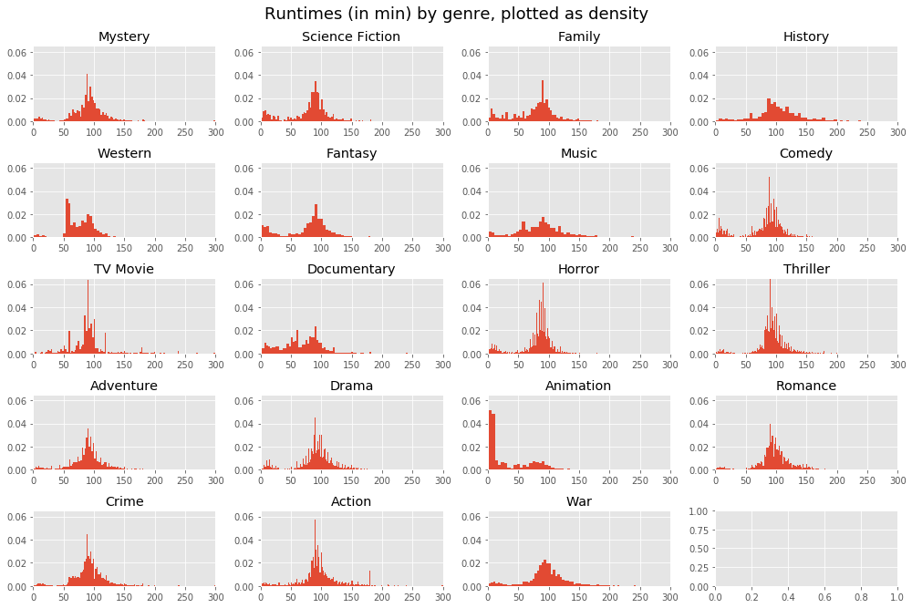

```python
def genre_runtimes_plotter(genre, ax):
    ax.hist(runtimes[genre], bins = "fd", density = True)

    ax.set_xlim(0, 300) # We know our data set doesn't contain movies longer than 300 minutes.
    ax.set_ylim(0, 0.065) # Make the plots have the same y-scale, this was chosen by first looking at all plots...

plot_by_genre_side_by_side("Runtimes (in min) by genre, plotted as density", genre_runtimes_plotter)
```

We see that most of the plots look similar and look like normal distrubutions. All of them have outliers which are either outside the plot (in the positive x direction) or between 0-40 minutes of runtime - except for the animation genre. In that case things are very different.. most animations are shorter than 50 minutes.

This leads to the question. Are there significant differences between the runtimes of different genres?

We will first run a one-way ANOVA test and then a t-test on each pair of genres and visualize all p-values with a matrix.

Let's go all in and test that for each combination of genres. Formulating our pair of hypothesis:

- $H_0:$ Genre runtimes are samples from the same distribution. Nothing interesting.
- $H_1:$ There are significant differences between genre runtimes.

We can't use the `runtimes` dict directly and we need to do some work on the data first - .. because movies can have multiple genres and in `movie_details_grouped_by_genre` samples can overlap. To solve this problem we will take the first genre in the movie genre list and consider it as "main" and the rest as less important sub-genres. The genres are not ordered alphabetically so we assume the first one is the most important.

```python
movie_details_grouped_by_main_genre = dict()
for genre in unique_genres:
    movie_details_grouped_by_main_genre[genre] = movie_details_genres[(movie_details_genres.genres.str.startswith(genre))
                                                                  & (movie_details_genres.release_date.dt.year > 1900)]
```

```python
non_overlapping_runtimes = dict()
for genre in unique_genres:
    genre_data = movie_details_grouped_by_main_genre[genre]
    non_overlapping_runtimes[genre] = genre_data[~genre_data.runtime.isnull()].runtime
```

Since our data set is very large, let's use a confidence level of $ \alpha_{c} = 0.1\% $.

```python
alpha = 0.001
```

```python
anova_pvalue = stats.f_oneway(*non_overlapping_runtimes.values()).pvalue
print(f"Running ANOVA resulted in a pvalue of {anova_pvalue}.")
if anova_pvalue < alpha:
    print("Null-hypothesis is probably false.")
else:
    print("Null-hypothesis can't be rejected with this confidence level.")
```

```
Running ANOVA resulted in a pvalue of 0.0.
Null-hypothesis is probably false.
```

ANOVA can’t tell us which specific groups were statistically significantly different from each other, only that at least two of the groups were.

Let's go all in and run t-test for each combination of genres. Formulating our hypothesis for each pair of genres:

- $H_0:$ `genre_1`'s runtimes is not not correlated with `genre_2`'s runtime.
- $H_1:$ `genre_1`'s runtimes and `genre_2`'s runtimes come from two significantly different distributions.

To visualize all p-values we will use a matrix:

```python
genres = list(unique_genres)

pvalue_matrix = pd.DataFrame(index = genres, columns = genres)
idx = pvalue_matrix.columns.union(pvalue_matrix.index)
pvalue_matrix = pvalue_matrix.reindex(index = list(idx)[:-1], columns = list(reversed(idx))[:-1], fill_value = 0)
```

Now we perform a t-test for each pair of genres with our $\alpha_{c} = 0.1\%$:

```python
for i in range(len(genres)):
    for j in range(i + 1, len(genres)):
        g1, g2 = genres[i], genres[j]
        r1, r2 = runtimes[g1], runtimes[g2]
        pvalue_matrix.loc[g1, g2] = stats.ttest_ind(r1, r2, equal_var = False).pvalue
```

Color all values less than alpha critical `green`.

```python
del genres
def color_green_or_gray(value):
    if np.isnan(value): return ("color: white; background-color: white")

    color = "green" if value < alpha else "gray"
    return "color: %s" % color
pvalue_matrix.style.applymap(color_green_or_gray).format("{:g}")
```

|  | War | Action | Crime | Romance | Animation | Drama | Adventure | Thriller | Horror | Documentary | TV Movie | Comedy | Music | Fantasy | Western | History | Family | Science Fiction |
| --- | --- | --- | --- | --- | --- | --- | --- | --- | --- | --- | --- | --- | --- | --- | --- | --- | --- | --- |
| Mystery | 1.71537e-16 | 1.35987e-55 | 9.47831e-10 | 3.39097e-55 | 0 | 1.97617e-13 | 0.0218563 | 3.57192e-19 | 2.91513e-77 | 0 | 0.00453458 | 1.01394e-79 | 0.530087 | 3.97887e-63 | 2.22596e-78 | 8.44005e-68 | 1.20182e-94 | 2.21691e-48 |
| Science Fiction | 2.66976e-84 | 7.07047e-224 | 5.20434e-115 | 1.43125e-229 | 0 | 1.57258e-147 | 6.07227e-70 | 1.0333e-154 | 0.661482 | 4.90954e-123 | 2.27939e-44 | 0.683083 | 7.01713e-42 | 0.000293117 | 5.71417e-07 | 3.86352e-162 | 1.07478e-07 | nan |
| Family | 7.21404e-127 | 0 | 1.76219e-204 | 0 | 0 | 2.06758e-268 | 2.41585e-130 | 5.3711e-270 | 4.34572e-10 | 4.02432e-78 | 9.46873e-75 | 2.36835e-14 | 2.35368e-83 | 0.313733 | 0.838846 | 2.49747e-212 | nan | nan |
| History | 1.51139e-18 | 9.76395e-19 | 1.00012e-49 | 8.19451e-21 | 0 | 6.1663e-53 | 3.30166e-60 | 2.52238e-43 | 6.67879e-194 | 0 | 3.22137e-37 | 8.55465e-195 | 4.78943e-69 | 9.31776e-177 | 5.53178e-195 | nan | nan | nan |
| Western | 8.50238e-114 | 6.22043e-259 | 9.12991e-154 | 6.97094e-263 | 0 | 5.52328e-185 | 2.09543e-104 | 1.07558e-192 | 2.22782e-08 | 3.24169e-56 | 1.04274e-67 | 2.55619e-11 | 5.8029e-70 | 0.268485 | nan | nan | nan | nan |
| Fantasy | 4.79749e-99 | 1.91006e-218 | 3.23115e-125 | 3.51117e-221 | 0 | 1.12939e-149 | 1.55703e-84 | 1.06176e-157 | 0.000101967 | 4.40946e-59 | 1.38543e-57 | 1.58996e-06 | 2.63248e-56 | nan | nan | nan | nan | nan |
| Music | 1.06373e-17 | 7.07485e-56 | 4.94706e-11 | 2.36523e-55 | 0 | 8.98869e-15 | 0.00408502 | 1.8152e-20 | 4.95979e-65 | 0 | 0.00108618 | 3.63376e-66 | nan | nan | nan | nan | nan | nan |
| Comedy | 1.45539e-108 | 0 | 7.95319e-267 | 0 | 0 | 0 | 1.96383e-128 | 0 | 0.174268 | 0 | 3.8295e-56 | nan | nan | nan | nan | nan | nan | nan |
| TV Movie | 8.56241e-06 | 1.69318e-15 | 0.21696 | 1.70824e-14 | 0 | 0.116341 | 0.216746 | 0.00368126 | 4.29488e-57 | 1.36208e-211 | nan | nan | nan | nan | nan | nan | nan | nan |
| Documentary | 1.48813e-302 | 0 | 0 | 0 | 0 | 0 | 0 | 0 | 2.52453e-244 | nan | nan | nan | nan | nan | nan | nan | nan | nan |
| Horror | 2.97893e-108 | 0 | 5.24469e-229 | 0 | 0 | 0 | 1.04044e-119 | 0 | nan | nan | nan | nan | nan | nan | nan | nan | nan | nan |
| Thriller | 0.0020686 | 1.38406e-26 | 0.00144047 | 2.89732e-26 | 0 | 0.000213013 | 5.6345e-12 | nan | nan | nan | nan | nan | nan | nan | nan | nan | nan | nan |
| Adventure | 1.04682e-11 | 6.22108e-47 | 9.51615e-05 | 1.41988e-46 | 0 | 5.51507e-07 | nan | nan | nan | nan | nan | nan | nan | nan | nan | nan | nan | nan |
| Drama | 3.7558e-06 | 4.26254e-51 | 0.582819 | 1.31093e-54 | 0 | nan | nan | nan | nan | nan | nan | nan | nan | nan | nan | nan | nan | nan |
| Animation | 0 | 0 | 0 | 0 | nan | nan | nan | nan | nan | nan | nan | nan | nan | nan | nan | nan | nan | nan |
| Romance | 0.0522962 | 0.399647 | 3.13758e-34 | nan | nan | nan | nan | nan | nan | nan | nan | nan | nan | nan | nan | nan | nan | nan |
| Crime | 4.5281e-06 | 1.51073e-34 | nan | nan | nan | nan | nan | nan | nan | nan | nan | nan | nan | nan | nan | nan | nan | nan |
| Action | 0.0190684 | nan | nan | nan | nan | nan | nan | nan | nan | nan | nan | nan | nan | nan | nan | nan | nan | nan |

These are all the cases for which we cannot reject the null-hypothesis with $\alpha = 0.1\%$:

```python
for genre1, content in pvalue_matrix.items():
    for genre2, value in content.to_dict().items():
        if value > alpha:
            print(f"{genre1}-{genre2}")
```

```
War-Thriller
War-Romance
War-Action
Action-Romance
Crime-TV Movie
Crime-Thriller
Crime-Drama
Drama-TV Movie
Adventure-Mystery
Adventure-Music
Adventure-TV Movie
Thriller-TV Movie
Horror-Science Fiction
Horror-Comedy
TV Movie-Mystery
TV Movie-Music
Comedy-Science Fiction
Music-Mystery
Fantasy-Family
Fantasy-Western
Western-Family
```

```python
# Free some large variables
del runtimes
del non_overlapping_runtimes
del movie_details_grouped_by_genre
```

### Correlation between runtime and rating

Is there a correlation between movie quality and the length of a movie?

First of all, we will take movies with at least 100 ratings (arbitrarily chosen).\ This discards movies with little vote counts and thus a garbage `vote_average`.

```python
have_runtime_and_rating = movie_details[(~movie_details.runtime.isnull()) & (~movie_details.vote_average.isnull())]
```

```python
high_rating_count = have_runtime_and_rating[have_runtime_and_rating.vote_count > 100]
high_rating_count.shape[0], have_runtime_and_rating.shape[0]
```

```
(5605, 226581)
```

```python
d, dd = high_rating_count.shape[0], have_runtime_and_rating.shape[0]
print(f"We are now working with about {d} / {dd} = {round(d / dd * 100, 2)}% of the original data set.");
```

```
We are now working with about 5605 / 226581 = 2.47% of the original data set.
```

```python
high_rating_count[["runtime", "vote_average"]].corr()
```

|  | runtime | vote_average |
| --- | --- | --- |
| runtime | 1.000000 | 0.253933 |
| vote_average | 0.253933 | 1.000000 |

However, let's explore things further with a scatter plot.

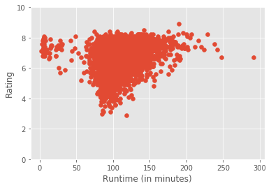

```python
plt.scatter(high_rating_count.runtime, high_rating_count.vote_average)
plt.xlabel("Runtime (in minutes)")
plt.ylabel("Rating")
plt.ylim(0, 10)
plt.show()
```

If we filter out the outliers:

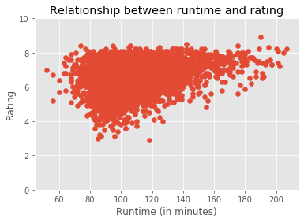

```python
filtered = high_rating_count[(high_rating_count.runtime > 50) & (high_rating_count.runtime < 210)]
plt.scatter(filtered.runtime, filtered.vote_average)
plt.title("Relationship between runtime and rating")
plt.xlabel("Runtime (in minutes)")
plt.ylabel("Rating")
plt.ylim(0, 10)
plt.show()
del filtered
```

We can see that there is definitely some structure. There's an interesting gap in the lower right corner. There is a severe lack of movies which are long and which have a low rating.

Maybe people got bored by watching a long film, turned it off, and didn't even bother to rate it? Or maybe long movies with a steadier story-telling are really better. We can't say for sure...

### Correlation between release year and rating

I'm sure you've heard people say older movies are better.. modern blockbusters are just cash-grabs.. directors stopped caring about art..

There are interesting articles and even some discussion happening in the comments: [Are Movies Getting Worse?](https://wmbriggs.com/post/4161/)\ [Why Dustin Hoffman Thinks Movies Are Getting Worse](https://www.cinemablend.com/new/Why-Dustin-Hoffman-Thinks-Movies-Getting-Worse-72424.html)

The first one even has a plot of how the opinion of critics and citizens is vastly different about modern movies.

Let's leave all that to the side and see what our data tells us:

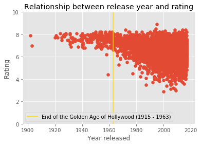

```python
plt.scatter(high_rating_count.release_date.dt.year, high_rating_count.vote_average)
plt.axvline(1963, color = "gold", label = "End of the Golden Age of Hollywood (1915 - 1963)")
plt.title("Relationship between release year and rating")
plt.xlabel("Year released")
plt.ylabel("Rating")
plt.ylim(0, 10)
plt.legend(loc = "lower left")
plt.show()
```

There is definitely some correlation. Although **our data set is biased** - there are way more recent movies in it and thus way more worse recent movies.\ Also young people are more likely to watch modern movies and give ratings (we chose movies with above 100 ratings, but older people don't cope well with technology and don't bother with ratings on web sites...)

All in all, the difference in there - but we **can't say for sure it is as big as the plot suggests**.

### Movies released by country

Choropleth maps are a pretty way to visualize data related to geography. Let's count how many movies were released in each country and plot them. To see the differences more clearly we will use a log scale for the color map.

We already got our shapefile (Admin 0 - Countries) from [Natural Earth Data's website](http://www.naturalearthdata.com/downloads/10m-cultural-vectors/).\ It is extracted in `data/ne_10m_admin_0_countries`.

```python
has_country = movies_released[~movies_released.country.isnull()]
has_country.shape[0], movies_released.shape[0]
```

```
(170726, 299247)
```

```python
d, dd = has_country.shape[0], movies_released.shape[0]
print(f"We are now working with about {d} / {dd} = {round(d / dd * 100, 2)}% of the original data set.");
```

```
We are now working with about 170726 / 299247 = 57.05% of the original data set.
```

First we need to group by country and count up the movies.

After that we do some well-documented (:D) hacky manual cleaning of data and then check to see the top countries.

```python
movie_count_by_country = has_country.groupby("country").count()
movie_count_by_country.insert(loc = 0, column = "bin", value = [0] * len(movie_count_by_country.index))

# These replaces were figured out after plotting the map for the first time and seeing which
# countries were gray (no data). Turned out some of them were actually a name which wasn't
# recognized by the shape file.
#
# Here we rename them.
#
# Note: All of this wouldn't be the case if somehow we translated the name
# to the more consistent ISO code of the country. There are libraries in python that do that - geonamescache.
# But it's source is http://www.geonames.org/. Which might be better but also has problems with some of the names below.
# To avoid additional complication and installing packages we just bite the manual replacement here.
#
# All in all, we handle most countries (not sure about some in Africa though, they may need to be added
# here later if we get movies for them and the names are not consistent).
movie_count_by_country.rename(index = {"Libyan Arab Jamahiriya": "Libya",
                                       "Congo": "Dem. Rep. Congo",
                                       "St. Vincent and the Grenadines": "Saint Vincent and the Grenadines",
                                       "St. Helena": "Saint Helena",
                                       "St. Kitts and Nevis": "Saint Kitts and Nevis",
                                       "St. Lucia": "Saint Lucia",
                                       "Sao Tome and Principe": "São Tomé and Principe",
                                       "Palestinian Territory": "West Bank and Gaza",
                                       "Cyprus": "N. Cyprus"
                                      }, inplace = True)

# Any column would do but we just get the counts out of "release_date"..
movie_counts = movie_count_by_country.release_date
movie_counts.sort_values(ascending = False).head(10)
```

```
country
United States of America    53552
Germany                     15513
United Kingdom              11791
France                      10878
Japan                        9111
India                        5264
Canada                       5239
Italy                        4998
Spain                        4270
Brazil                       3394
Name: release_date, dtype: int64
```

Reds look good and fit with the rest of our notebook :).

```python
bin_count = 7

cmap = plt.get_cmap("Reds")
scheme = [cmap(i / bin_count) for i in range(bin_count)]
```

Now we use `np.geomspace` which is like `np.linspace` but with a log scale (there is also `np.logspace` but it takes start and end point as exponents to a base, while `geomspace` uses start and end points directly).

```python
bins = np.geomspace(movie_counts.min(), movie_counts.max(), bin_count)
```

After that we assign each country a bin.

```python
movie_count_by_country.bin = np.digitize(movie_counts, bins)
```

The code below is a modified version of a sample by Ramiro Gómez (Last edited: January 18, 2016).\ You can find that here: https://ramiro.org/notebook/basemap-choropleth/

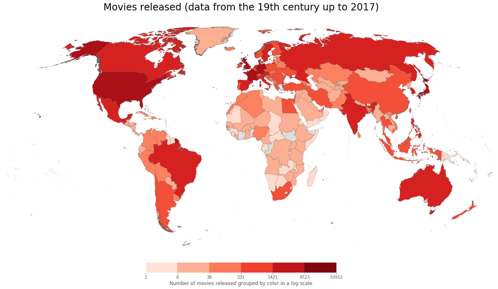

```python
fig = plt.figure(figsize = (22, 12))
fig.suptitle("Movies released (data from the 19th century up to 2017)", fontsize = 24, y = .92)

ax = fig.add_subplot(111, fc = "white", frame_on = False)

m = Basemap(projection = "robin", lon_0 = 0)
m.drawmapboundary(color = "white")

gray_countries = list()

m.readshapefile("data/ne_10m_admin_0_countries/ne_10m_admin_0_countries", "units", color = "#444444", linewidth = 0.2)
for info, shape in zip(m.units_info, m.units):
    possible_names = {info["NAME"], info["NAME_EN"], info["NAME_LONG"], info["FORMAL_EN"]}
    intersection = possible_names.intersection(movie_count_by_country.index)
    if len(intersection) == 0:
        color = "#dddddd"
        gray_countries.append(possible_names)
    else:
        if len(intersection) != 1:
            print("?!?.. intersection of country names has more than 1 element:", intersection)
        country_name = intersection.pop()
        color = scheme[movie_count_by_country.loc[country_name, "bin"]]

    patches = [Polygon(np.array(shape), True)]
    pc = PatchCollection(patches)
    pc.set_facecolor(color)
    ax.add_collection(pc)

# Cover Antarctica so legend can be placed over it
ax.axhspan(0, 1000 * 1800, facecolor = "white", edgecolor = "white", zorder = 2)

ax_legend = fig.add_axes([0.35, 0.14, 0.3, 0.03], zorder = 3)

norm = mpl.colors.LogNorm(movie_counts.min(), movie_counts.max())
cb = mpl.colorbar.ColorbarBase(ax_legend, cmap = cmap, boundaries = bins, ticks = bins, norm = norm, orientation = "horizontal")

cb.set_label("Number of movies released grouped by color in a log scale")
cb.ax.set_xticklabels([str(round(i))[:-2] for i in bins])

plt.show()
```

Gray means there is no data for the country.

! Note: ! After I ran the code for the first time I investigated gray countries to see if it was a problem with the data set or there were just no movies produced there. It turned out I needed to change the way I linked the names of some countries with the shape file. (e.g. the historical name of "Libyan Arab Jamahiriya" to the modern "Libya"). The countries which needed changing were checked manually with the code below:

```python
#for c in gray_countries:
#    print(c)
```

```python
#for i in movie_count_by_country.index:
#    print(i)
```

### Movie posters color intensity

Is there a link between movie genres and poster color intensity?

The data we are going to use is the following set from kaggle.com:

- [Poster Image Dataset of Hollywood Movies](https://www.kaggle.com/phiitm/movie-posters) provided by Pranav Hari (Last updated in 2020)

We are going to extract that archive in `data/poster_downloads`.

! Note: ! This data set is large in size (about 8000 images, 116 MB). I provided a much smaller version but you can download the full one.

For each image we calculate the average intensity of each channel and then the overall intesity.\ In the end `posters_rgb_intensities` contains tuples of the format `(movie_info, [r, g, b, total])`).

```python
posters_rgb_intensities = list()

# Make sample_size None to read all posters in the folder instead of an explicit sample size.
sample_size = None

# Reads a sample of the posters in the data set
for filename in os.listdir("data/poster_downloads"):
    imdb_id = filename.split("_")[1][:-4]

    # Checks if there is a movie with that given imdb_id, if not we don't read the image
    mask = movie_details_genres.imdb_id == imdb_id
    if np.any(mask):
        image = skimage.io.imread("data/poster_downloads/" + filename)
        info = movie_details_genres[mask].to_dict(orient = "list")

        # If the format for the image is not RGB we skip it
        if len(image.shape) != 3: continue
        if image.shape[2] != 3: continue


        # Calculate the sum of the r, g and b channels
        r, g, b = image[:, :, 0], image[:, :, 1], image[:, :, 2]

        # Here we calculate the average intensity of each channel, and overall
        # Gamma correction is not really an issue because we compare relatively to other posters later
        r_intensity, g_intensity, b_intensity = r.mean(), g.mean(), b.mean()

        gray_scale = image.mean(axis = 2).round().astype(np.uint8)
        intensity = gray_scale.mean()

        posters_rgb_intensities.append((info, [r_intensity, g_intensity, b_intensity, intensity]))

    if sample_size is not None:
        if sample_size == 0:
            break
        sample_size -= 1
```

```python
def get_all_channels_per_genre(grouped, channel):
    """
    `grouped` - a dict mapping genres to lists of arrays of pre-calculated r, g, b, overall intensities
    `channel` - which channel to extract (index 0-4 where 4 is overall intensity)
    """
    result = dict()
    for genre, movies in grouped.items():
        result[genre] = []
        for movie in movies:
            result[genre].append(movie[1][channel])
    return result

def run_anova_on_channel(grouped, channel, alpha):
    """
    Uses _get_all_channels_per_genre_ to retrieve the calculated channel information.
    `grouped` - a dict mapping genres to lists of arrays of pre-calculated r, g, b, overall intensities
    `channel` - is one of: r, g, b, overall_intensity
    `alpha` - test critical value
    """
    channel_index = 0
    if channel == "r": pass
    elif channel == "g": channel_index = 1
    elif channel == "b": channel_index = 2
    elif channel == "overall_intensity": channel_index = 3
    else: raise ValueError

    anova_pvalue = stats.f_oneway(*get_all_channels_per_genre(grouped, channel_index).values()).pvalue
    print(f"Running ANOVA on channel \"{channel}\" of images resulted in a pvalue of {anova_pvalue}.")
    if anova_pvalue < alpha:
        print("Null-hypothesis is probably false.")
    else:
        print(f"Null-hypothesis can't be rejected with confidence level of {alpha}.")
```

Now we group posters to see see if there is significant difference in intensities between genres:

```python
posters_grouped_by_genre = dict()

for image in posters_rgb_intensities:
    info = image[0]

    # Take just the first genre.
    # We called it "main" genre, they are not ordered alphabetically so we assume the first one is the most important.
    genre = info["genres"][0].split("|")[0]
    if genre == "": continue
    posters_grouped_by_genre[genre] = posters_grouped_by_genre.get(genre, []) + [image]
```

Run anova on each channel with the mean values we calculated earlier.

The test runs on groups (determined by genre) which contain the average intensity of a channel for each poster corresponding to a movie in that genre.

The hypothesis which we are going to test:

- $H_0:$ Average intensities of channels are from the same distribution. Nothing interesting.
- $H_1:$ There are significant differences between intensities of certain colors in movie posters.

```python
alpha = 0.01
run_anova_on_channel(posters_grouped_by_genre, "r", alpha)
```

```
Running ANOVA on channel "r" of images resulted in a pvalue of 8.761208322425462e-43.
Null-hypothesis is probably false.
```

```python
run_anova_on_channel(posters_grouped_by_genre, "g", alpha)
```

```
Running ANOVA on channel "g" of images resulted in a pvalue of 8.468345429608294e-45.
Null-hypothesis is probably false.
```

```python
run_anova_on_channel(posters_grouped_by_genre, "b", alpha)
```

```
Running ANOVA on channel "b" of images resulted in a pvalue of 4.037597152134077e-37.
Null-hypothesis is probably false.
```

```python
run_anova_on_channel(posters_grouped_by_genre, "overall_intensity", alpha)
```

```
Running ANOVA on channel "overall_intensity" of images resulted in a pvalue of 1.2874771542612296e-46.
Null-hypothesis is probably false.
```

! Note: ! Running on all 8000 posters results in all p-values being less than 1e-100. If we run on a smaller sample we will get bigger p-values.

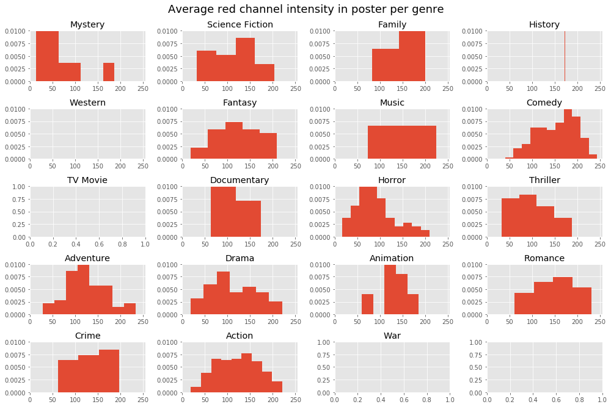

```python
red_channels_per_genre = get_all_channels_per_genre(posters_grouped_by_genre, 0)

def channel_means_plotter(genre, ax):
    if genre not in red_channels_per_genre: return
    ax.hist(red_channels_per_genre[genre], bins = "fd", density = True)
    ax.set_xlim(0, 255) # Pixel intensities go from 0 to 255
    ax.set_ylim(0, 0.01) # Make the plots have the same y-scale, this was chosen by first looking at all plots...

plot_by_genre_side_by_side("Average red channel intensity in poster per genre", channel_means_plotter)
```

Some plots might be empty (no posters, too small of a sample size).\ Others have too little data (increase sample size for a better picture).

```python
for k, v in red_channels_per_genre.items():
    print(f"{k}: {len(v)}")
```

```
Horror: 150
Comedy: 313
Science Fiction: 27
Action: 209
Drama: 150
Fantasy: 36
Family: 8
Crime: 21
Documentary: 5
Adventure: 54
Thriller: 34
Animation: 10
Romance: 22
Western: 1
Mystery: 11
Music: 4
History: 1
```

### Ideas for further analysis or things that I tried but didn't quite work

- Gathering movie subtitles and doing NLP/counting words per minute? I was going to gather data myself but unfortunately subtitle data bases work based on video file hash and not movie title (to ensure timing is right). So I gave up on that idea but it would be definitely interesting.

#### Predicting genre based on overview (short description)

We will do NLP on movie overviews and then train a model to see how accuratly it can predict the genre.\ Let's use the previous grouping we did by main genre and see how many movies we get for each one:

```python
min_count = None
for genre, movies in movie_details_grouped_by_main_genre.items():
    with_overview = movies[~movies.overview.isnull()]
    print(f"{genre}: {len(with_overview)}")
    if min_count is None or min_count > len(with_overview):
        min_count = len(with_overview)
print(f"\nMin count is {min_count}, we are going to use that for a sample size.")
```

```
Mystery: 2071
Science Fiction: 2482
Family: 3579
History: 1232
Western: 2895
Fantasy: 2238
Music: 7985
Comedy: 28311
TV Movie: 1700
Documentary: 22840
Horror: 9364
Thriller: 5954
Adventure: 4088
Drama: 41203
Animation: 8652
Romance: 5739
Crime: 4961
Action: 12530
War: 1426

Min count is 1232, we are going to use that for a sample size.
```

Since the counts are vastly different let's take the same number of movies from each genre. We can use the genre with the least movies for the sample size.

```python
genre_samples = dict()
for genre, movies in movie_details_grouped_by_main_genre.items():
    sample = movies[~movies.overview.isnull()].sample(min_count, random_state = 12)
    genre_samples[genre] = sample
```

Stemming vs lemmatizing?

- "The goal of both stemming and lemmatization is to reduce inflectional forms and sometimes derivationally related forms of a word to a common base form.\ However, the two words differ in their flavor. Stemming usually refers to a crude heuristic process that chops off the ends of words in the hope of achieving this goal correctly most of the time, and often includes the removal of derivational affixes. Lemmatization usually refers to doing things properly with the use of a vocabulary and morphological analysis of words, normally aiming to remove inflectional endings only and to return the base or dictionary form of a word, which is known as the lemma."
  - Cited from: https://nlp.stanford.edu/IR-book/html/htmledition/stemming-and-lemmatization-1.html

```python
documents = list()
y = list() # This is an array saying the value of the target feature of each document (used for training)

stemmer = WordNetLemmatizer()
for genre, movies in genre_samples.items():
    for overview in movies.overview.values:
        # Clean puncuation and lemmatize words
        stripped = overview.lower().translate(str.maketrans('', '', string.punctuation))
        stripped = [stemmer.lemmatize(word) for word in stripped.split()]

        documents.append(' '.join(stripped))
    y += [hash(genre)] * len(movies)
```

Use TF-IDF (term frequency–inverse document frequency) to reflect importancy of words:

```python
vectorizer = TfidfVectorizer(max_features = 1500, min_df = 5, max_df = 0.7, stop_words = "english")
X = vectorizer.fit_transform(documents)
```

Now we split the data into train and tests (80% to 20%):

```python
X_train, X_test, y_train, y_test = train_test_split(X, y, test_size = 0.2, random_state = 12)
```

... and now I have no idea what to do. I hope what I have done so far is not very very wrong but I don't know how to continue. What model to chose or if the ratio of tests to trains is right??\ .. Maybe I will finish this after the machine learning course :)

#### Plotting actors in a graph based on movies they have done together

`AllMoviesCastingRaw.csv` is another file from our original data set. It contains information about cast and crew members. We will match actor names if they have done a movie together and then plot a graph.

```python
cast_details = pd.read_csv("data/350000_movies_dataset/AllMoviesCastingRaw.csv", sep = ";", thousands = ",",
                            encoding = "utf-8-sig", index_col = [0], low_memory = False)
actor_gender_columns = [f"actor{i}_gender" for i in range(1, 6)]
cast_details = cast_details.drop(actor_gender_columns + ["actor_number", "producer_name", "producer_number",
                                                         "screeplay_name", "editor_name", "director_gender",
                                                         "director_number"], axis = 1)
```

```python
cast_details.head()
```

| id | actor1_name | actor2_name | actor3_name | actor4_name | actor5_name | director_name |
| --- | --- | --- | --- | --- | --- | --- |
| 2 | Turo Pajala | Susanna Haavisto | Matti Pellonpää | Eetu Hilkamo | none | Aki Kaurismäki |
| 3 | Matti Pellonpää | Kati Outinen | Sakari Kuosmanen | Esko Nikkari | Kylli Köngäs | Aki Kaurismäki |
| 5 | Tim Roth | Antonio Banderas | Jennifer Beals | Madonna | Marisa Tomei | Allison Anders |
| 6 | Emilio Estevez | Cuba Gooding Jr. | Denis Leary | Jeremy Piven | Peter Greene | Stephen Hopkins |
| 8 | none | none | none | none | none | Timo Novotny |

We'll hash the strings so the comparisons are faster (integers vs text).

```python
actor_name_columns = [f"actor{i}_name" for i in range(1, 6)]
cast_details_hashed = cast_details[actor_name_columns].copy()
for actor_col in actor_name_columns:
    cast_details_hashed[actor_col] = cast_details_hashed[actor_col].apply(lambda x: 0 if x == "none" else hash(x))
```

```python
edges = dict()

sample_size = 100 # None
for (movie_index, info) in cast_details_hashed.iterrows():
    for i in range(0, len(actor_name_columns) - 1):
        a1 = info[actor_name_columns[i]]
        if a1 == 0: continue
        for j in range(i + 1, len(actor_name_columns)):
            a2 = info[actor_name_columns[j]]
            if a2 == 0: continue
            edges[(a1, a2)] = edges.get((a1, a2), 0) + 1
    if sample_size is not None:
        if sample_size == 0:
            break
        sample_size -= 1
```

```python
edges_list = [(k[0], k[1], v) for k, v in edges.items()]
```

```python
movie_graph = nx.Graph()
movie_graph.add_weighted_edges_from(edges_list)
```

```python
pos = nx.spring_layout(movie_graph, k = 0.1, iterations = 20)
```

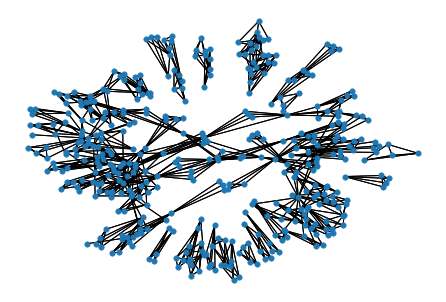

```python
weights = nx.get_edge_attributes(movie_graph, "weight")
nx.draw(movie_graph, pos, node_size = 30)
nx.draw_networkx_edges(movie_graph, pos)
plt.show()
```

It looks messy and even messier on a large movie sample.\ Maybe we can try further assosication by scraping wikipedia articles and doing NLP?!?\ ... For now let's stop here... :)

#### Taking average ratings of directors

I guess there is something interesting which can be analyzed with this. Just an idea..

```python
movie_details_with_director = movie_details.join(cast_details.director_name)
movie_details_with_director = movie_details_with_director[movie_details_with_director.director_name != "none"]
```

```python
high_rating_count = movie_details_with_director[movie_details_with_director.vote_count > 100]
```

```python
high_rating_count.groupby("director_name").vote_average.mean().sort_values(ascending = False)
```

```
director_name
Aditya Chopra       8.900000
Kurt Kuenne         8.400000
Carl Tibbetts       8.400000
Yasujirō Ozu        8.200000
Masaki Kobayashi    8.200000
                      ...
Vic Armstrong       3.700000
Jason Friedberg     3.683333
Chris Fisher        3.600000
Joseph Sargent      3.500000
Roger Christian     2.900000
Name: vote_average, Length: 2363, dtype: float64
```

### References

#### Data

- 350 000+ movies from themoviedb.org, Stephanerappeneau, 2017, https://www.kaggle.com/stephanerappeneau/350-000-movies-from-themoviedborg
- Natural Earth Data, Admin 0 - Countries, http://www.naturalearthdata.com/downloads/10m-cultural-vectors/
- Poster Image Dataset of Hollywood Movies, Pranav Hari, 2020, https://www.kaggle.com/phiitm/movie-posters

#### Citations

- Stephen Follows, "How many films are released each year?", 2017, https://stephenfollows.com/how-many-films-are-released-each-year/
- List of movies over 300 minutes: https://en.wikipedia.org/wiki/List_of_longest_films
- Ramiro Gómez, "Creating a Choropleth Map of the World in Python using Basemap", 2016, https://ramiro.org/notebook/basemap-choropleth/